# Case Study - Bellabeat

JMK

2025-03-01

# Introduction

Bellabeat is a health-focused smart tech manufacturer. The Bellabeat product line of wearable tech captures user activity data to empower women with knowledge about their own health and habits.

The key objective for this case study is to analyze smart device usage data to identify trends in how consumers use non-Bellabeat smart devices. These insights will then be applied to the Bellabeat app in order to understand how the trends could benefit Bellabeat users. The analysis will explore how these insights could influence the Bellabeat content marketing strategy, helping the company better align its products with consumer needs and preferences.

We will adhere to the A.P.P.A.S.A. Data Analysis Cycle framework to identify key trends and provide recommendations that can drive business results, including increased market share and improved consumer sentiment.

# 1. Ask Phase

### 1.1 Business Objective

The Bellabeat team has obtained non-Bellabeat smart device usage data. As Bellabeat data analysts, we are tasked with exploring key trends throughout this data and addressing the following questions:

- What are the behavioral trends of users of non-Bellabeat wearable devices?
- How might these trends apply to Bellabeat customers?
- How could these trends help influence the Bellabeat content marketing strategy?

### 1.2 Stakeholders:

- Urška Sršen: Cofounder & Chief Creative Officer
- Sando Mur: Cofounder
- Bellabeat Data Analytics team

Given our internal audience, we will curate a presentation that includes all technical details while ensuring complete transparency to facilitate seamless feedback and future collaborations.

Our stakeholders’ vision of project success includes a comprehensive exploratory analysis with actionable insights, aimed at:

- Optimizing the Bellabeat content marketing strategy
- More effectively leveraging Bellabeat app capabilities
- Driving increased customer sentiment through health optimization, ultimately fostering customer loyalty, attracting new users, and expanding market share

# 2. Prepare Phase

## 2.1 Available Data

In this phase, we will collect and prepare the necessary data for analysis.

The available data is **FitBit Fitness Tracker Data** (CC0: Public Domain, dataset made available through Mobius, hosted on Kaggle.

### 2.1.1 Metadata

The metadata informs us that the datasets are open-source and available for our use without asking permission.

These datasets contain a sample of personal fitness tracker data from 33 users who consented to submit their personal tracker data – which includes hourly output for calories burned, step counts, distance, and sleep monitoring.

### 2.1.2 Verification

We have sorted and filtered the data, creating Pivot Tables in spreadsheets to ensure data accuracy, specifically focusing on the integrity of the date ranges and user IDs.

Below is a summary breakdown of the datasets.

| Table Name | File Type | Description |
| --- | --- | --- |
| dailyActivity_merged | CSV | Daily Activity: steps, distance, activity-level distance, activity-level minutes, calories |
| hourlyCalories_merged | CSV | Hourly Calories |
| hourlySteps_merged | CSV | Hourly Steps |
| sleepDay_merged | CSV | Daily Sleep: minutes asleep, minutes in bed |

Through this process, we have found some users with significantly low volumes of entries – indicating suboptimal device usage – and therefore we have created entry count thresholds per user, removing those user who have not met these thresholds. The thresholds and resulting figures across the datasets are as follows:

| Table Name | Original Total Unique Users | Threshold | New Total Unique Users | Total Days |
| --- | --- | --- | --- | --- |
| dailyActivity_merged | 33 | 10 entries (days)* | 32 | 31 |
| hourlyCalories_merged | 33 | 240 entries (hours)** | 32 | 31 |
| hourlySteps_merged | 33 | 240 entries (hours) | 32 | 31 |
| sleepDay_merged | 24 | 10 entries (days)*** | 15 | 31 |

`*`10 days was chosen as the threshold i.e., 10 days minimum of data entry per user.

`**`240 hours was chosen to align with the 10 day threshold.

`***`sleepDay_merged now only includes data entries for 15 users, which is less than ideal although sleep is a critical metric for our analysis.

## 2.2 Building the Environment

We have chosen R for this analysis due to its strong capabilities in data manipulation, visualization, and statistical analysis. It is particularly well-suited for working wiith structured datasets and provides a wide range of packages – such as tidyverse, ggplot2, and lubridate – that streamline the data cleaning, exploration, and visualization process. R also integrates seamlessly with R Markdown, making it easy to document and present the analysis in a clear and reproducible format.

### 2.2.1 Load Libraries

We will use the following packages for our analysis:

- tidyverse
- lubridate
- data.table
- stringr
- plotly
- janitor
- here
- skimr
- ggrepel
- moments
- markdown

```r
library(tidyverse)
library(lubridate)
library(data.table)
library(stringr)
library(plotly)
library(janitor)
library(here)
library(skimr)
library(ggrepel)
library(moments)
library(markdown)
```

### 2.2.2 Import Datasets

We will import the following datasets:

- dailyActivity_merged
- hourlyCalories_merged
- hourlySteps_merged
- sleepDay_merged

```r
daily_activity <- read_csv("Wearable data/dailyActivity_merged_cleaned.csv")
hourly_calories <- read_csv("Wearable data/hourlyCalories_merged_cleaned.csv")
hourly_steps <- read_csv("Wearable data/hourlySteps_merged_cleaned.csv")
daily_sleep <- read_csv("Wearable data/sleepDay_merged_cleaned.csv")
```

### 2.2.3 Preview

Before continuing, let’s preview our datasets to ensure completeness and accuracy.

```r
head(daily_activity)
str(daily_activity)
head(hourly_calories)
str(hourly_calories)
head(hourly_steps)
str(hourly_steps)
head(daily_sleep)
str(daily_sleep)
```

[output not shown]

# 3. Process Phase

## 3.1 Cleaning

### 3.1.1 Count Unique Users

We’ll count the users included in our datasets by checking the count of unique IDs.

```r
print(daily_activity %>% summarize(unique_ids = n_distinct(Id, na.rm = TRUE)))
```

```
## # A tibble: 1 × 1
##   unique_ids
##        <int>
## 1         32
```

```r
print(hourly_calories %>% summarize(unique_ids = n_distinct(Id, na.rm = TRUE)))
```

```
## # A tibble: 1 × 1
##   unique_ids
##        <int>
## 1         32
```

```r
print(hourly_steps %>% summarize(unique_ids = n_distinct(Id, na.rm = TRUE)))
```

```
## # A tibble: 1 × 1
##   unique_ids
##        <int>
## 1         32
```

```r
print(daily_sleep %>% summarize(unique_ids = n_distinct(Id, na.rm = TRUE)))
```

```
## # A tibble: 1 × 1
##   unique_ids
##        <int>
## 1         15
```

These results are exactly as we expected them, due to our work with Pivot Tables in the verification step (2.1.2).

### 3.1.2 Count missing data and nulls

```r
# check for missing or blank values
daily_activity %>%
  filter(Id == "" | is.na(Id) |
           ActivityDate == "" | is.na(ActivityDate))
```

```
## # A tibble: 0 × 15
## # ℹ 15 variables: Id <dbl>, ActivityDate <chr>, TotalSteps <dbl>,
## #   TotalDistance <dbl>, TrackerDistance <dbl>, LoggedActivitiesDistance <dbl>,
## #   VeryActiveDistance <dbl>, ModeratelyActiveDistance <dbl>,
## #   LightActiveDistance <dbl>, SedentaryActiveDistance <dbl>,
## #   VeryActiveMinutes <dbl>, FairlyActiveMinutes <dbl>,
## #   LightlyActiveMinutes <dbl>, SedentaryMinutes <dbl>, Calories <dbl>
```

```r
hourly_calories %>%
  filter(Id == "" | is.na(Id) |
           ActivityHour == "" | is.na(ActivityHour))
```

```
## # A tibble: 0 × 3
## # ℹ 3 variables: Id <dbl>, ActivityHour <chr>, Calories <dbl>
```

```r
hourly_steps %>%
  filter(Id == "" | is.na(Id) |
           ActivityHour == "" | is.na(ActivityHour))
```

```
## # A tibble: 0 × 3
## # ℹ 3 variables: Id <dbl>, ActivityHour <chr>, StepTotal <dbl>
```

```r
daily_sleep %>%
  filter(Id == "" | is.na(Id) |
           SleepDay == "" | is.na(SleepDay))
```

```
## # A tibble: 0 × 5
## # ℹ 5 variables: Id <dbl>, SleepDay <chr>, TotalSleepRecords <dbl>,
## #   TotalMinutesAsleep <dbl>, TotalTimeInBed <dbl>
```

No blanks or N/As exist across the Id or date/date-time columns of the data frames.

### 3.1.3 Count Duplicates

Next, we’ll count duplicates in our datasets.

```r
sum(duplicated(daily_activity))
```

```
## [1] 0
```

```r
sum(duplicated(hourly_calories))
```

```
## [1] 0
```

```r
sum(duplicated(hourly_steps))
```

```
## [1] 0
```

```r
sum(duplicated(daily_sleep))
```

```
## [1] 3
```

We’ll take a look at the three duplicates in daily_sleep in the next step.

#### 3.1.3.1 Inspect Duplicates

Because daily_sleep appears to contain three duplicates, we’ll inspect them further by isolating rows appearing more than once to determine how to proceed.

```r
# Identify duplicate sleep records by grouping the same user on the same day
daily_sleep %>%
  group_by(Id, SleepDay) %>%
  filter(n() > 1) %>%
  print(n = 10)
```

```
## # A tibble: 6 × 5
## # Groups:   Id, SleepDay [3]
##           Id SleepDay        TotalSleepRecords TotalMinutesAsleep TotalTimeInBed
##        <dbl> <chr>                       <dbl>              <dbl>          <dbl>
## 1 4388161847 5/5/2016 12:00…                 1                471            495
## 2 4388161847 5/5/2016 12:00…                 1                471            495
## 3 4702921684 5/7/2016 12:00…                 1                520            543
## 4 4702921684 5/7/2016 12:00…                 1                520            543
## 5 8378563200 4/25/2016 12:0…                 1                388            402
## 6 8378563200 4/25/2016 12:0…                 1                388            402
```

#### 3.1.3.2 Remove Duplicates

Since we can see all six occurrences where three rows are duplicated, we’ll permanently remove one occurrence (the second) of each duplicate row by overwriting with only the unique rows.

```r
# Remove duplicate sleep records, keeping only the first per user per day
daily_sleep <- daily_sleep %>%
  distinct(Id, SleepDay, .keep_all = TRUE)
```

Finally we confirm the changes.

```r
daily_sleep %>%
  filter(duplicated(select(., Id, SleepDay))) %>%
  print(n = 10)
```

```
## # A tibble: 0 × 5
## # ℹ 5 variables: Id <dbl>, SleepDay <chr>, TotalSleepRecords <dbl>,
## #   TotalMinutesAsleep <dbl>, TotalTimeInBed <dbl>
```

### 3.1.4 Clean(column names)

We want to ensure our columns are clean and uniform with lower case.

```r
# Standardize columns across all datasets
daily_activity <- clean_names(daily_activity)
hourly_calories <- clean_names(hourly_calories)
hourly_steps <- clean_names(hourly_steps)
daily_sleep <- clean_names(daily_sleep)
```

## 3.2 Formatting

### 3.2.1 Lowercase Column Names

We’ll convert all names across our data frames to lowercase to help prevent case-sensitive errors.

```r
# Convert all column names to lowercase for consistency
names(daily_activity) <- tolower(names(daily_activity))
names(hourly_calories) <- tolower(names(hourly_calories))
names(hourly_steps) <- tolower(names(hourly_steps))
names(daily_sleep) <- tolower(names(daily_sleep))
```

### 3.2.2 Update Variable Type

The variable types across data frames specifically in two columns require updating. Each id column and treats the user IDs as `<dbl>` (i.e., double, for decimals); each date column treats the date as `<chr>`.

#### 3.2.2.1 Update ID Column Data Type

First, we’ll address the id columns. *(An initial instinct was to convert `<dbl>` to `<int>`, but user IDs stored as integers may lead to formatting issues (e.g., scientific notation) or accidental calculations, so we will convert `<dbl>` to `<chr>`.)*

```r
# Convert user ID columns to character type in all datasets
daily_activity <- daily_activity %>%
  mutate(id = as.character(id))
hourly_calories <- hourly_calories %>%
  mutate(id = as.character(id))
hourly_steps <- hourly_steps %>%
  mutate(id = as.character(id))
daily_sleep <- daily_sleep %>%
  mutate(id = as.character(id))
```

#### 3.2.2.2 Update Date Column Data Type

Second, we’ll address the date/date-time columns.

```r
# Convert date and datetime columns to proper date formats
daily_activity <- daily_activity %>%
  mutate(activity_date = mdy(activity_date))
hourly_calories <- hourly_calories %>%
  mutate(activity_hour = mdy_hms(activity_hour))
hourly_steps <- hourly_steps %>%
  mutate(activity_hour = mdy_hms(activity_hour))
```

##### 3.2.2.2.1 Caveat: daily_sleep Date Column

Examining the daily_sleep data frame’s date-time column (sleep_day), we have noted that the rows in preview appear to only include midnight, which does make sense because this dataset contains *daily* sleep time totals for each user. However, we’ll extract the unique time values to gain certainty that no other times exist within the column.

```r
# Convert sleep day column to POSIXct format and extract unique times
daily_sleep$sleep_day <- as.POSIXct(daily_sleep$sleep_day, format = "%m/%d/%Y %I:%M:%S %p")
unique(format(daily_sleep$sleep_day, "%H:%M:%S"))
```

[output not shown]

Since sleep_day does in fact only contain midnight across all rows, and because we don’t need the time component, we’ll first convert the column to a proper date-time object, and secondly we’ll add a pipe to drop the time component.

```r
# Convert sleep day column to POSIXct format and then extract the date
daily_sleep <- daily_sleep %>%
  mutate(sleep_day = as.POSIXct(sleep_day, format = "%m/%d/%Y %H:%M:%S") %>% as.Date())
```

Now we have a proper `<date>` format.

### 3.2.3 Duplicate Date Columns for Merging

#### 3.2.3.1 daily_activity & daily_sleep

Later on, we’ll want to merge daily_activity and daily_sleep; we’ll also want to keep track of the original data frames for clarity, so we’ll duplicate the date columns with a new equivalent name. *(This redundancy may provide clarity in the future.)*

```r
# Duplicate the 'date' column in both datasets, with aligned names
daily_activity <- daily_activity %>%
  mutate(date = activity_date)
daily_sleep <- daily_sleep %>%
  mutate(date = sleep_day)
```

#### 3.2.3.2 hourly_[metrics]

We’ll apply the same concept to our hourly data frames (calories, steps).

```r
# # Duplicate the 'date-time' column in both datasets, with aligned names
hourly_calories <- hourly_calories %>%
  mutate(date = activity_hour)
hourly_steps <- hourly_steps %>%
  mutate(date = activity_hour)
```

#### 3.2.3.3 Rename Originals

Finally we’ll rename our original date columns so they are aligned yet distinguishable across data frames.

We’ll use sleep_day as the baseline, only removing the underscore.

```r
# Rename date and time columns across all datasets
daily_activity <- daily_activity %>%
  rename(activityday = activity_date)
hourly_calories <- hourly_calories %>%
  rename(calorieshour = activity_hour)
hourly_steps <- hourly_steps %>%
  rename(stepshour = activity_hour)
daily_sleep <- daily_sleep %>%
  rename(sleepday = sleep_day)
```

## 3.3 Pre-Merging Validation

We want to ensure that the values of our hourly datasets (hourly_calories, hourly_steps) match daily_activity. We will sum the hourly data in order to validate accuracy and consistency.

### 3.3.1 Create Summarized Datasets

First we’ll extract the date, group by id and date, and sum the respective hourly values to get daily totals.

```r
# Aggregate hourly data to calculate daily totals for calories and steps
hourly_calories_daily <- hourly_calories %>%
  mutate(date = as.Date(calorieshour)) %>%
  group_by(id, date) %>%
  summarize(daily_total_calories = sum(calories, na.rm = TRUE), .groups = 'drop')

hourly_steps_daily <- hourly_steps %>%
  mutate(date = as.Date(stepshour)) %>%
  group_by(id, date) %>%
  summarize(daily_total_steps = sum(step_total, na.rm = TRUE), .groups = 'drop')
```

### 3.3.2 Merge with daily_activity

Now we can merge the aggregated hourly data with daily_activity in a new data frame.

We will ensure that all rows from the daily_activity dataset are preserved, even when there are no corresponding matches in other dataset – to retain a complete dataset for accurate insights.

```r
# Merge daily activity data with aggregated hourly calories and steps data
validation_data <- daily_activity %>%
  left_join(hourly_calories_daily, by = c("id", "date")) %>%
  left_join(hourly_steps_daily, by = c("id", "date"))

glimpse(validation_data)
```

```
## Rows: 936
## Columns: 18
## $ id                         <chr> "1503960366", "1624580081", "1644430081", "…
## $ activityday                <date> 2016-04-12, 2016-04-12, 2016-04-12, 2016-0…
## $ total_steps                <dbl> 13162, 8163, 10694, 6697, 678, 11875, 4414,…
## $ total_distance             <dbl> 8.50, 5.31, 7.77, 4.43, 0.47, 8.34, 2.74, 7…
## $ tracker_distance           <dbl> 8.50, 5.31, 7.77, 4.43, 0.47, 8.34, 2.74, 7…
## $ logged_activities_distance <dbl> 0.000000, 0.000000, 0.000000, 0.000000, 0.0…
## $ very_active_distance       <dbl> 1.88, 0.00, 0.14, 0.00, 0.00, 3.31, 0.19, 1…
## $ moderately_active_distance <dbl> 0.55, 0.00, 2.30, 0.00, 0.00, 0.77, 0.35, 0…
## $ light_active_distance      <dbl> 6.06, 5.31, 5.33, 4.43, 0.47, 4.26, 2.20, 6…
## $ sedentary_active_distance  <dbl> 0.00, 0.00, 0.00, 0.00, 0.00, 0.00, 0.00, 0…
## $ very_active_minutes        <dbl> 25, 0, 2, 0, 0, 42, 3, 13, 28, 2, 0, 44, 4,…
## $ fairly_active_minutes      <dbl> 13, 0, 51, 0, 0, 14, 8, 9, 13, 21, 0, 19, 1…
## $ lightly_active_minutes     <dbl> 328, 146, 256, 339, 55, 227, 181, 306, 320,…
## $ sedentary_minutes          <dbl> 728, 1294, 1131, 1101, 734, 1157, 706, 1112…
## $ calories                   <dbl> 1985, 1432, 3199, 2030, 2220, 2390, 1459, 2…
## $ date                       <date> 2016-04-12, 2016-04-12, 2016-04-12, 2016-0…
## $ daily_total_calories       <dbl> 1988, 1433, 3200, 2031, 2195, 2386, 1460, 2…
## $ daily_total_steps          <dbl> 13158, 8163, 10694, 6697, 678, 11875, 4414,…
```

### 3.3.3 Calculate Correlation Values

Using the new ‘validation_data,’ we can calculate correlation values against their counterpart totals in daily_activity.

```r
# Calculate correlation values
cor(validation_data$daily_total_calories, validation_data$calories, use = "complete.obs")
```

```
## [1] 0.9855864
```

```r
cor(validation_data$daily_total_steps, validation_data$total_steps, use = "complete.obs")
```

```
## [1] 0.9850039
```

These results showing very strong correlation tell us that our summarized hourly data:

- Closely matches the daily totals
- Serves as a reliable source for analysis
- Indicates strong internal consistency, meaning the FitBit users logged data fairly regularly

Note: The <1.0 correlations remind us that the wearable data logging isn’t perfect – this is a limitation.

## 3.4 Merging

We will merge our daily-level datasets – retaining all rows from daily_activity because since daily_activity has the most complete listing of users and dates – by the id and date columns.

```r
# Merge daily activity sleep, and aggregated hourly data into final dataset
final_data <- daily_activity %>%
  left_join(daily_sleep, by = c("id", "date")) %>%
  left_join(hourly_calories_daily, by = c("id", "date")) %>%
  left_join(hourly_steps_daily, by = c("id", "date"))
```

## 3.5 Validation

Now that we have completed the merges, we will validate that the resulting final_data matches our expectations.

### 3.5.1 Validate Dimensions

```r
nrow(final_data)
```

```
## [1] 936
```

```r
summary(final_data)
```

```
##       id             activityday          total_steps    total_distance
##  Length:936         Min.   :2016-04-12   Min.   :    0   Min.   : 0.000
##  Class :character   1st Qu.:2016-04-19   1st Qu.: 3790   1st Qu.: 2.620
##  Mode  :character   Median :2016-04-26   Median : 7441   Median : 5.265
##                     Mean   :2016-04-26   Mean   : 7654   Mean   : 5.501
##                     3rd Qu.:2016-05-04   3rd Qu.:10734   3rd Qu.: 7.720
##                     Max.   :2016-05-12   Max.   :36019   Max.   :28.030
##
##  tracker_distance logged_activities_distance very_active_distance
##  Min.   : 0.000   Min.   :0.0000             Min.   : 0.000
##  1st Qu.: 2.620   1st Qu.:0.0000             1st Qu.: 0.000
##  Median : 5.265   Median :0.0000             Median : 0.220
##  Mean   : 5.487   Mean   :0.1086             Mean   : 1.509
##  3rd Qu.: 7.713   3rd Qu.:0.0000             3rd Qu.: 2.090
##  Max.   :28.030   Max.   :4.9421             Max.   :21.920
##
##  moderately_active_distance light_active_distance sedentary_active_distance
##  Min.   :0.0000             Min.   : 0.000        Min.   :0.000000
##  1st Qu.:0.0000             1st Qu.: 1.945        1st Qu.:0.000000
##  Median :0.2400             Median : 3.365        Median :0.000000
##  Mean   :0.5697             Mean   : 3.344        Mean   :0.001613
##  3rd Qu.:0.8000             3rd Qu.: 4.790        3rd Qu.:0.000000
##  Max.   :6.4800             Max.   :10.710        Max.   :0.110000
##
##  very_active_minutes fairly_active_minutes lightly_active_minutes
##  Min.   :  0.00      Min.   :  0.00        Min.   :  0.0
##  1st Qu.:  0.00      1st Qu.:  0.00        1st Qu.:127.0
##  Median :  4.00      Median :  7.00        Median :199.0
##  Mean   : 21.25      Mean   : 13.62        Mean   :193.2
##  3rd Qu.: 32.00      3rd Qu.: 19.00        3rd Qu.:264.2
##  Max.   :210.00      Max.   :143.00        Max.   :518.0
##
##  sedentary_minutes    calories         date               sleepday
##  Min.   :   0.0    Min.   :   0   Min.   :2016-04-12   Min.   :2016-04-12
##  1st Qu.: 729.0    1st Qu.:1830   1st Qu.:2016-04-19   1st Qu.:2016-04-19
##  Median :1057.0    Median :2134   Median :2016-04-26   Median :2016-04-26
##  Mean   : 990.2    Mean   :2305   Mean   :2016-04-26   Mean   :2016-04-26
##  3rd Qu.:1226.8    3rd Qu.:2794   3rd Qu.:2016-05-04   3rd Qu.:2016-05-04
##  Max.   :1440.0    Max.   :4900   Max.   :2016-05-12   Max.   :2016-05-12
##                                                        NA's   :560
##  total_sleep_records total_minutes_asleep total_time_in_bed
##  Min.   :1.000       Min.   : 59.0        Min.   : 65.0
##  1st Qu.:1.000       1st Qu.:373.0        1st Qu.:413.8
##  Median :1.000       Median :436.5        Median :467.5
##  Mean   :1.122       Mean   :428.4        Mean   :466.9
##  3rd Qu.:1.000       3rd Qu.:492.0        3rd Qu.:527.8
##  Max.   :3.000       Max.   :775.0        Max.   :843.0
##  NA's   :560         NA's   :560          NA's   :560
##  daily_total_calories daily_total_steps
##  Min.   :  65         Min.   :    0
##  1st Qu.:1828         1st Qu.: 3727
##  Median :2124         Median : 7388
##  Mean   :2306         Mean   : 7591
##  3rd Qu.:2781         3rd Qu.:10694
##  Max.   :4551         Max.   :36019
##  NA's   :6            NA's   :6
```

The summary() function confirms that key variables like steps, calories, and sleep values fall within expected ranges. The presence of NAs in our sleep-related columns aligns with our understanding that not all users logged sleep data.

### 3.5.2 Validate Unique Users

```r
# Count unique users
final_data %>% summarize(unique_users = n_distinct(id))
```

```
## # A tibble: 1 × 1
##   unique_users
##          <int>
## 1           32
```

### 3.5.3 Validate Time Series

```r
# Identify and filter rows with duplicate data
final_data %>%
  count(id, date) %>%
  filter(n > 1)
```

```
## # A tibble: 0 × 3
## # ℹ 3 variables: id <chr>, date <date>, n <int>
```

# 4. Analyze & Share Phases

## 4.1 Exploratory Data Analysis (EDA): Part I

We have successfully assessed the data quality of our datasets, processed them, and developed a basic understanding of their structures and contents. Now, we will manually calculate summary statistics to gain a deeper understanding of the daily data. To extract the most relevant insights, we will focus on calories, steps, minutes asleep, and time in bed.

### 4.1.1 Central Tendency

#### 4.1.1.1 Mean

To calculate the mean, we will use the following approach:

```r
# Calculate the mean of key metrics across final_data
final_data %>%
  summarize(
    across(
  c("daily_total_calories", "daily_total_steps", "total_minutes_asleep", "total_time_in_bed"),
  ~ mean(.x, na.rm = TRUE)
    )
  ) %>%
  rename(
    mean_calories = daily_total_calories,
    mean_steps = daily_total_steps,
    mean_sleep_minutes = total_minutes_asleep,
    mean_bed_minutes = total_time_in_bed
    )
```

```
## # A tibble: 1 × 4
##   mean_calories mean_steps mean_sleep_minutes mean_bed_minutes
##           <dbl>      <dbl>              <dbl>            <dbl>
## 1         2306.      7591.               428.             467.
```

#### 4.1.1.2 Median

To calculate the median, we will use the following approach:

```r
# Calculate the median of key metrics across final_data
final_data %>%
  summarize(
    across(
      c("daily_total_calories", "daily_total_steps", "total_minutes_asleep", "total_time_in_bed"),
      ~ median(.x, na.rm = TRUE)
    )
  ) %>%
  rename(
    median_calories = daily_total_calories,
    median_steps = daily_total_steps,
    median_sleep_minutes = total_minutes_asleep,
    median_bed_minutes = total_time_in_bed
    )
```

```
## # A tibble: 1 × 4
##   median_calories median_steps median_sleep_minutes median_bed_minutes
##             <dbl>        <dbl>                <dbl>              <dbl>
## 1           2124.        7388.                 436.               468.
```

### 4.1.2 Dispersion

#### 4.1.2.1 Standard Deviation

To calculate the standard deviation, we will use the following approach:

```r
# Calculate the standard deviation of key metrics across final_data
final_data %>%
  summarize(
    across(
      c("daily_total_calories", "daily_total_steps", "total_minutes_asleep", "total_time_in_bed"),
      ~ sd(.x, na.rm = TRUE)
    )
  ) %>%
  rename(
    sd_calories = daily_total_calories,
    sd_steps = daily_total_steps,
    sd_sleep_minutes = total_minutes_asleep,
    sd_bed_minutes = total_time_in_bed
    )
```

```
## # A tibble: 1 × 4
##   sd_calories sd_steps sd_sleep_minutes sd_bed_minutes
##         <dbl>    <dbl>            <dbl>          <dbl>
## 1        693.    5103.             101.           99.5
```

#### 4.1.2.2 Variance

To calculate the variance, we will use the following approach:

```r
# Calculate variance of key metrics across final_data
final_data %>%
  summarize(
    across(
      c("daily_total_calories", "daily_total_steps", "total_minutes_asleep", "total_time_in_bed"),
      ~ var(.x, na.rm = TRUE)
    )
  ) %>%
  rename(
    var_calories = daily_total_calories,
    var_steps = daily_total_steps,
    var_sleep_minutes = total_minutes_asleep,
    var_bed_minutes = total_time_in_bed
    )
```

```
## # A tibble: 1 × 4
##   var_calories var_steps var_sleep_minutes var_bed_minutes
##          <dbl>     <dbl>             <dbl>           <dbl>
## 1      480931. 26040891.            10173.           9894.
```

Calories and steps show high variability, so we will use box plots to explore them further.

##### 4.1.2.2.1 Variance Drill Down

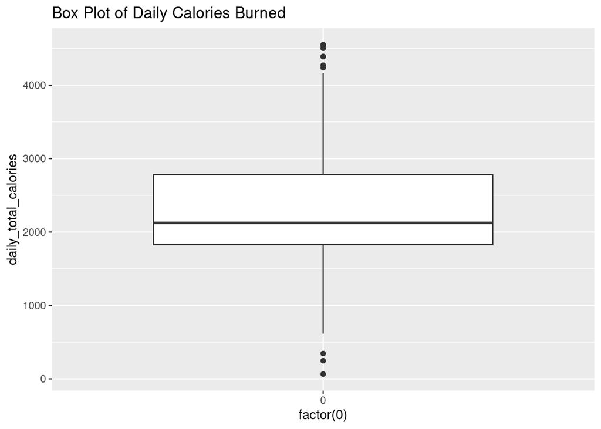

```r
# Create a box plot of daily calories burned, excluding missing values
final_data %>%
  filter(!is.na(daily_total_calories)) %>%
  ggplot(aes(x = factor(0), y = daily_total_calories)) +
  geom_boxplot() +
  labs(title = "Box Plot of Daily Calories Burned")
```

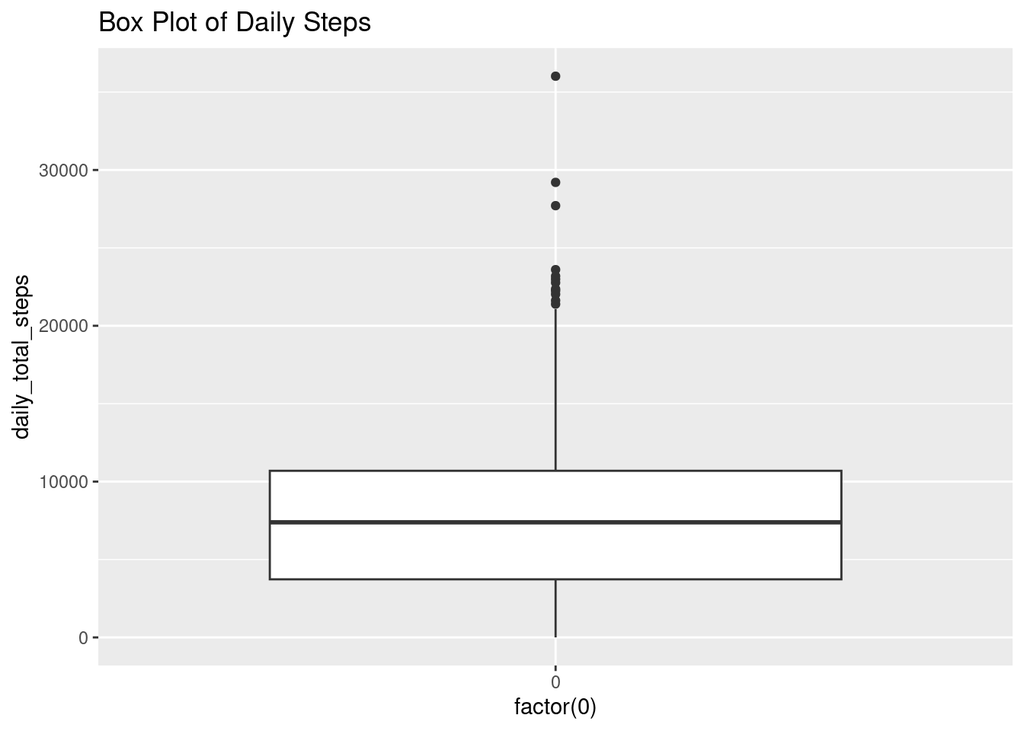

```r
# Create a box plot of daily steps, excluding missing values
final_data %>%
  filter(!is.na(daily_total_steps)) %>%
  ggplot(aes(x = factor(0), y = daily_total_steps)) +
  geom_boxplot() +
  labs(title = "Box Plot of Daily Steps")
```

Both box plots display significant outliers, which help explain the variance results – therefore we will move on to the next analysis.

#### 4.1.2.3 Range

To calculate the range, we will use the following approach:

```r
# Calculate range of key metrics across final_data
final_data %>%
  summarize(
    across(
      c("daily_total_calories", "daily_total_steps", "total_minutes_asleep", "total_time_in_bed"),
      ~ max(.x, na.rm = TRUE) - min(.x, na.rm = TRUE)
    )
  ) %>%
  rename(
    range_calories = daily_total_calories,
    range_steps = daily_total_steps,
    range_sleep_minutes = total_minutes_asleep,
    range_bed_minutes = total_time_in_bed
    )
```

```
## # A tibble: 1 × 4
##   range_calories range_steps range_sleep_minutes range_bed_minutes
##            <dbl>       <dbl>               <dbl>             <dbl>
## 1           4486       36019                 716               778
```

#### 4.1.2.4 Interquartile Range (IQR)

To calculate the IQR, we will use the following approach:

```r
# Calculate IQR of key metrics across final_data
final_data %>%
  summarize(
    across(
      c("daily_total_calories", "daily_total_steps", "total_minutes_asleep", "total_time_in_bed"),
      ~ IQR(.x, na.rm = TRUE)
    )
  ) %>%
  rename(
    iqr_calories = daily_total_calories,
    iqr_steps = daily_total_steps,
    iqr_sleep_minutes = total_minutes_asleep,
    iqr_bed_minutes = total_time_in_bed
    )
```

```
## # A tibble: 1 × 4
##   iqr_calories iqr_steps iqr_sleep_minutes iqr_bed_minutes
##          <dbl>     <dbl>             <dbl>           <dbl>
## 1         953.     6966.               119             114
```

#### 4.1.2.5 Distribution Shape

##### 4.1.2.5.1 Skewness and Kurtosis

To calculate the skewness and kurtosis, we will use the following approach:

```r
# Calculate skewness and kurtosis of key metrics across final_data and reshape the results for readability
final_data %>%
  summarize(
    across(
      c("daily_total_calories", "daily_total_steps", "total_minutes_asleep", "total_time_in_bed"),
      list(
        skew = ~ skewness(.x, na.rm = TRUE),
        kurt = ~ kurtosis(.x, na.rm = TRUE)
      ),
        .names = "{col}_{fn}"
    )
  ) %>%
  pivot_longer(
    everything(),
    names_to = c("variable", "stat"),
    names_pattern = "^(.*)_(skew|kurt)$",
    values_to = "value"
  ) %>%
  mutate(value = round(value, 3))
```

```
## # A tibble: 8 × 3
##   variable             stat   value
##   <chr>                <chr>  <dbl>
## 1 daily_total_calories skew   0.604
## 2 daily_total_calories kurt   3.26
## 3 daily_total_steps    skew   0.649
## 4 daily_total_steps    kurt   4.14
## 5 total_minutes_asleep skew  -0.537
## 6 total_minutes_asleep kurt   4.89
## 7 total_time_in_bed    skew  -0.604
## 8 total_time_in_bed    kurt   6.19
```

##### 4.1.2.5.2 Distribution Plots

To visualize distribution, we will use the following approach:

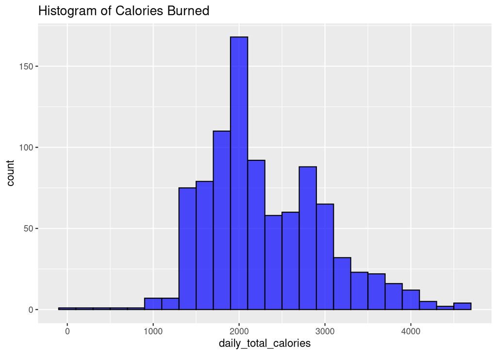

```r
# Create histogram of daily calories burned, excluding missing values
final_data %>%
  filter(!is.na(daily_total_calories)) %>%
  ggplot(aes(x = daily_total_calories)) +
  geom_histogram(binwidth = 200, fill = "blue", color = "black", alpha = 0.7) +
  labs(title = "Histogram of Calories Burned")
```

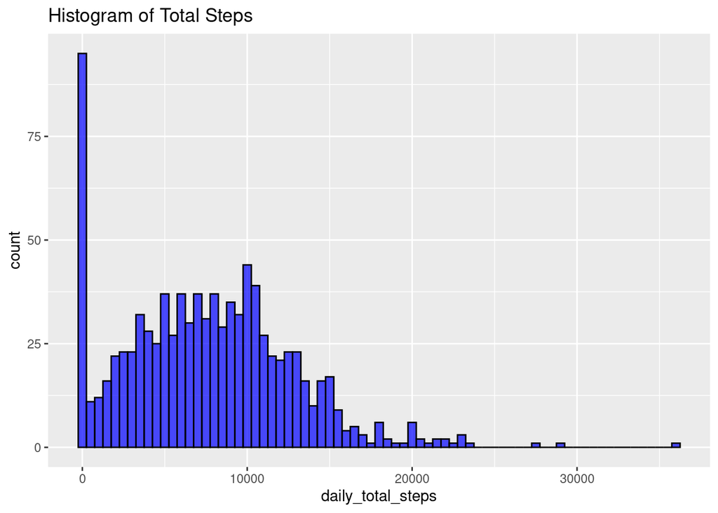

```r
# Create histogram of daily steps, excluding missing values
final_data %>%
  filter(!is.na(daily_total_steps)) %>%
  ggplot(aes(x = daily_total_steps)) +
  geom_histogram(binwidth = 500, fill = "blue", color = "black", alpha = 0.7) +
  labs(title = "Histogram of Total Steps")
```

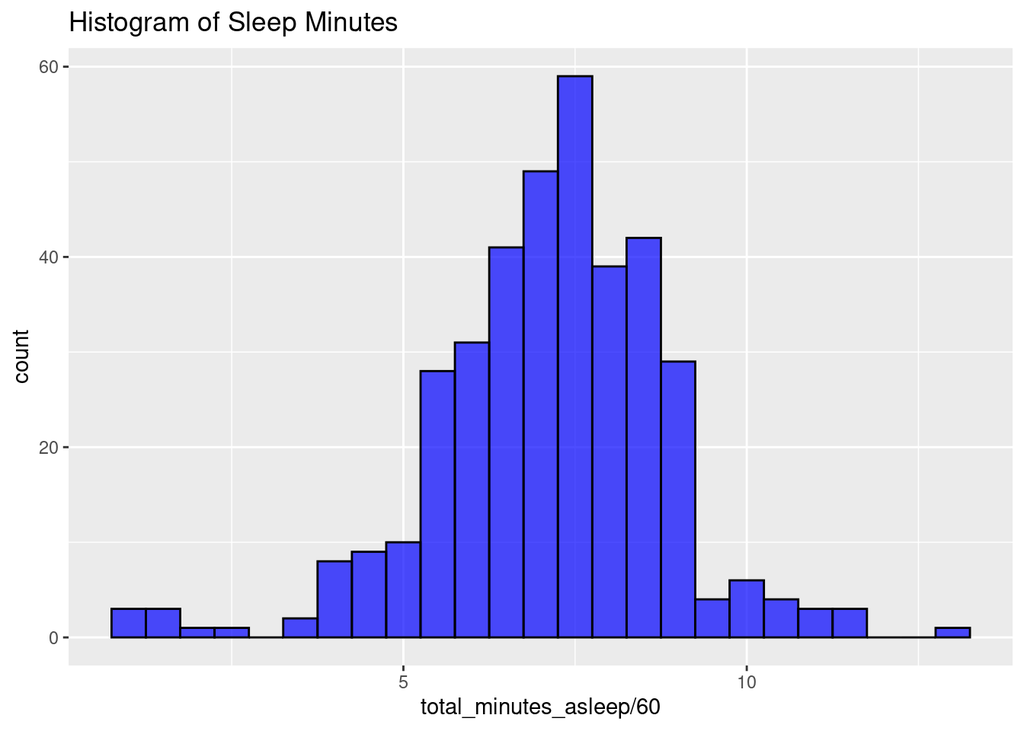

```r
# Create histogram of daily minutes asleep, excluding missing values
final_data %>%
  filter(!is.na(total_minutes_asleep)) %>%
  ggplot(aes(x = total_minutes_asleep / 60)) + # Convert minutes to hours
  geom_histogram(binwidth = 0.5, fill = "blue", color = "black", alpha = 0.7) +
  labs(title = "Histogram of Sleep Minutes")
```

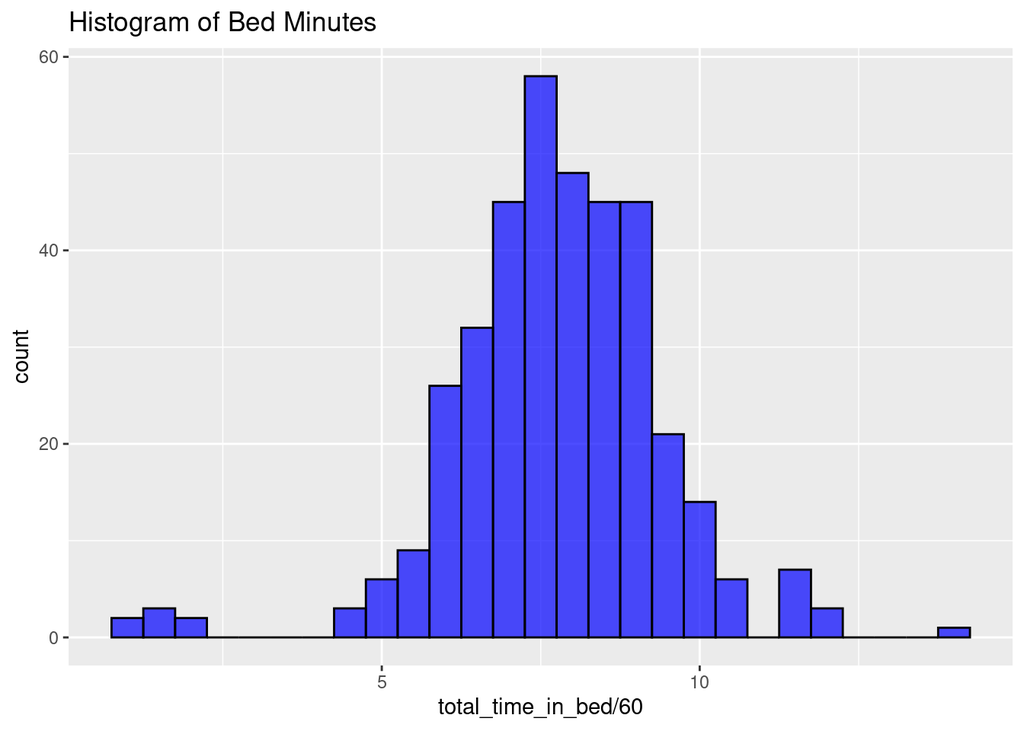

```r
# Create histogram of daily minutes in bed, excluding missing values
final_data %>%
  filter(!is.na(total_time_in_bed)) %>%
  ggplot(aes(x = total_time_in_bed / 60)) + # Convert minutes to hours
  geom_histogram(binwidth = 0.5, fill = "blue", color = "black", alpha = 0.7) +
  labs(title = "Histogram of Bed Minutes")
```

## 4.2 EDA Part II: Bivariate Relationships

Now we will explore 1:1 relationships between our key variables – we’ll exclude total_time_in_bed but soon we’ll return to that variable.

### 4.2.1 Viz: Calories vs. Steps

To visualize the relationship between calorie burn and steps, we will use the following approach:

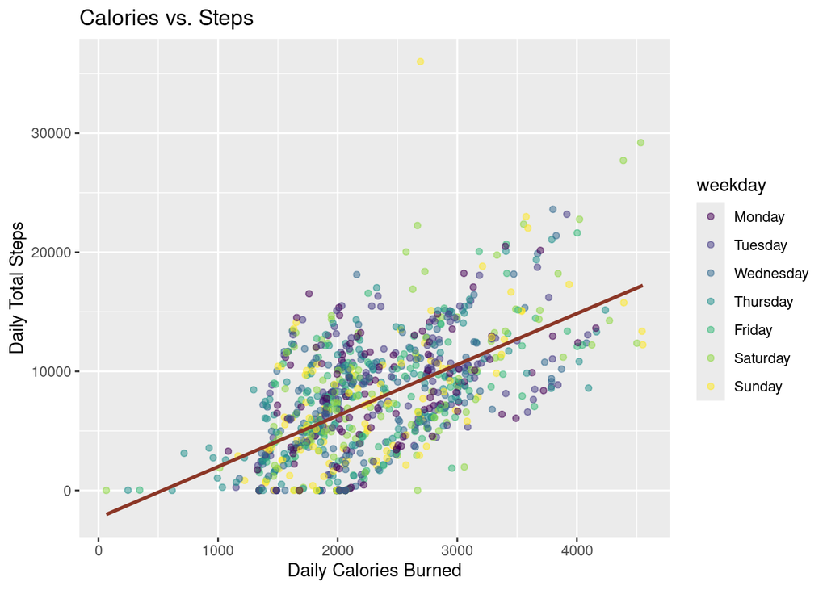

```r
# Create a scatter plot of daily calories burned vs. daily steps, colored by weekday
# Add a linear regression line (without confidence interval) to show trend
final_data %>%
  filter(!is.na(daily_total_calories) & !is.na(daily_total_steps)) %>%
  mutate(weekday = factor(weekdays(activityday),
                          levels = c("Monday", "Tuesday", "Wednesday", "Thursday", "Friday", "Saturday", "Sunday"))) %>%
  ggplot(aes(x = daily_total_calories, y = daily_total_steps, color = weekday))+
  geom_point(alpha = 0.5)+
  geom_smooth(method = "lm", se = FALSE, color = "tomato4")+
  labs(
    title = "Calories vs. Steps",
    x = "Daily Calories Burned",
    y = "Daily Total Steps"
  ) +
  scale_color_viridis_d()
```

The trend line shows a moderate positive correlation between calories burned and steps: as step counts increase, calories burned tend to increase as well.

This pattern is expected – walking directly contributes to calories expenditure. Furthermore, the clustering of most data points between 0–15,000 steps and 1,500–3,000 calories burned reflects typical daily activity ranges.

Interestingly, calorie burn from walking appears consistent across weekdays and weekends.

#### 4.2.1.1 Viz: Calories vs. Steps with Threshold & Averages

For presentation purposes, we may choose to add a labeled 7,000-step threshold line – based on a [JAMA Network Open study](https://jamanetwork.com/journals/jamanetworkopen/fullarticle/2783711) which states that in a cohort study of 2,110 adults, participants taking at least 7,000 steps per day had a 50% to 70% lower risk of all-cause mortality compared to those taking fewer than 7,000 steps.

First, we will calculate the percentage of users whose average daily steps met and did not meet the threshold, to add to our visualization:

```r
# Calculate percentage of users meeting and not meeting 7000 daily step goal
final_data %>%
  group_by(id) %>%
  summarize(avg_daily_steps = mean(daily_total_steps, na.rm = TRUE)) %>%
  summarize(
    percent_met = mean(avg_daily_steps >= 7000) * 100,
    percent_not_met = mean(avg_daily_steps < 7000) * 100
  )
```

```
## # A tibble: 1 × 2
##   percent_met percent_not_met
##         <dbl>           <dbl>
## 1        53.1            46.9
```

Now, we will incorporate these percentages into our visualization alongside the threshold line to enhance interpretability and highlight user distribution relative to the benchmark.

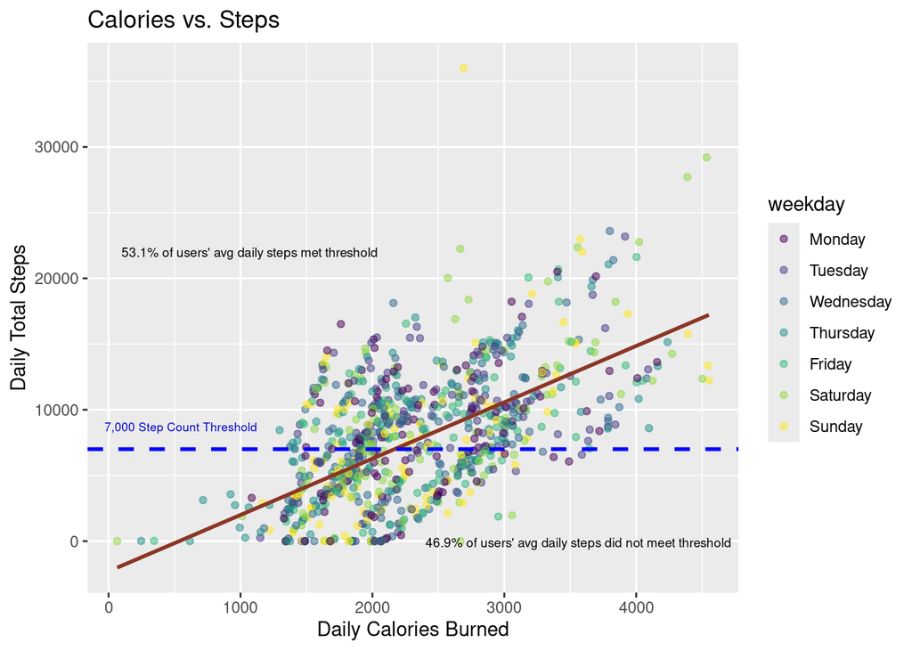

```r
# Create scatter plot of daily calories burned vs. daily steps, colored by weekday
# Add a linear regression line to show trend
# Highlight the 7,000 step count threshold with a dashed line and annotations for user segments above and below

final_data %>%
  filter(!is.na(daily_total_calories) & !is.na(daily_total_steps)) %>%
  mutate(weekday = factor(weekdays(activityday),
                          levels = c("Monday", "Tuesday", "Wednesday", "Thursday", "Friday", "Saturday", "Sunday"))) %>%
  ggplot(aes(x = daily_total_calories, y = daily_total_steps, color = weekday))+
  geom_point(alpha = 0.5)+
  geom_smooth(method = "lm", se = FALSE, color = "tomato4")+
  geom_hline(yintercept = 7000, linetype = "dashed", color = "blue", size = 1)+
  annotate("text", x = 550, y = 8700, label = "7,000 Step Count Threshold", color = "blue3", size = 2.3)+
  annotate("text", x = 100, y = 22000, label = "53.1% of users' avg daily steps met threshold", color = "black", size = 2.5, hjust = 0)+
  annotate("text", x = 2400, y = -100, label = "46.9% of users' avg daily steps did not meet threshold", color = "black", size = 2.5, hjust = 0)+
  labs(
    title = "Calories vs. Steps",
    x = "Daily Calories Burned",
    y = "Daily Total Steps"
  ) +
  scale_color_viridis_d()
```

### 4.2.2 Viz: Calories vs. Sleep

To visualize the relationship between calorie expenditure and sleep, we will use the following approach:

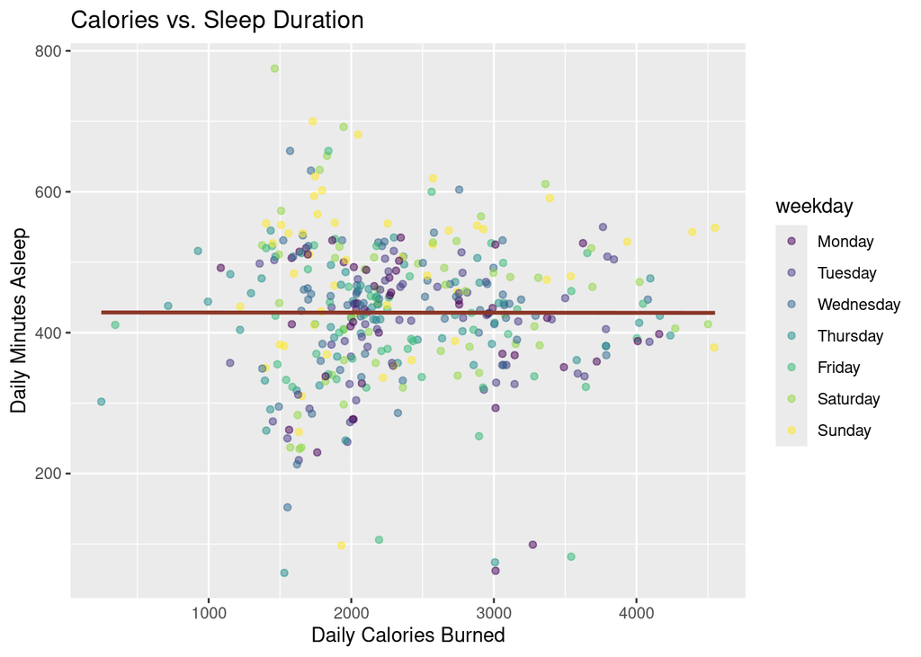

```r
# Create scatter plot of daily calories burned vs. daily sleep duration, colored by weekday
# Add a linear regression line to show trend
final_data %>%
    filter(!is.na(daily_total_calories) & !is.na(total_minutes_asleep)) %>%
  mutate(weekday = factor(weekdays(activityday),
                          levels = c("Monday", "Tuesday", "Wednesday", "Thursday", "Friday", "Saturday", "Sunday"))) %>%
  ggplot(aes(x = daily_total_calories, y = total_minutes_asleep, color = weekday))+
  geom_point(alpha = 0.5)+
  geom_smooth(method = "lm", se = FALSE, color = "tomato4")+
  labs(
    title = "Calories vs. Sleep Duration",
    x = "Daily Calories Burned",
    y = "Daily Minutes Asleep"
  ) +
  scale_color_viridis_d()
```

The horizontal line indicates that there’s no meaningful correlation between calorie exhaustion and sleep.

Next, we will further explore the relationship by calculating the correlation between the variables.

#### 4.2.2.1 Correlation: Calories vs. Sleep

```r
# Calculate correlation between daily calories burned and total minutes asleep
cor(final_data$daily_total_calories, final_data$total_minutes_asleep, use = "complete.obs")
```

```
## [1] -0.001060087
```

This result reflects an extremely weak negative relationship, indicating that no strong relationship exists between the variables.

To dive deeper, we will examine whether calories burned on one day are associated with sleep duration on the following day.

##### 4.2.2.1.1 Viz: Calories vs. Next Day Sleep

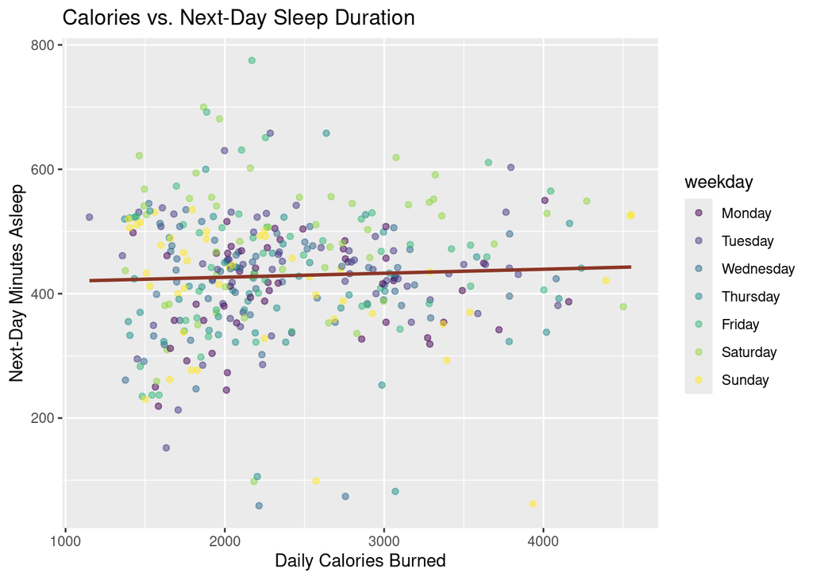

```r
# Create scatter plot of daily calories burned vs. next-day sleep duration, colored by weekday
# Add a linear regression line to show trend
final_data %>%
  arrange(id, activityday) %>%
  group_by(id) %>%
  mutate(next_day_sleep = lead(total_minutes_asleep)) %>% # Create new column to shift sleep minutes by user and day
  ungroup() %>%
  filter(!is.na(daily_total_calories) & !is.na(next_day_sleep)) %>%
  mutate(weekday = factor(weekdays(activityday),
                          levels = c("Monday", "Tuesday", "Wednesday", "Thursday", "Friday", "Saturday", "Sunday"))) %>%
  ggplot(aes(x = daily_total_calories, y = next_day_sleep, color = weekday))+
  geom_point(alpha = 0.5)+
  geom_smooth(method = "lm", se = FALSE, color = "tomato4")+
  labs(
    title = "Calories vs. Next-Day Sleep Duration",
    x = "Daily Calories Burned",
    y = "Next-Day Minutes Asleep"
  )+
  scale_color_viridis_d()
```

Again, we will further explore the relationship by calculating the correlation between the variables.

###### 4.2.2.1.1.1 Correlation: Calories vs. Next Day Sleep

```r
# Calculate the correlation between daily calories burned and next-day sleep duration
final_data %>%
  arrange(id, activityday) %>%
  group_by(id) %>%
  mutate(next_day_sleep = lead(total_minutes_asleep)) %>%
  ungroup() %>%
  filter(!is.na(daily_total_calories) & !is.na(next_day_sleep)) %>%
  summarize(correlation = cor(daily_total_calories, next_day_sleep, use = "complete.obs"))
```

```
## # A tibble: 1 × 1
##   correlation
##         <dbl>
## 1      0.0463
```

We’re seeing a slight shift in the relationship – there appears to be a negligible correlation between calories burned and sleep duration the following day; both relationships are too weak to suggest a reliable association.

### 4.2.3 Viz: Steps vs. Sleep

To visualize the relationship between steps and sleep duration, we will use the following approach:

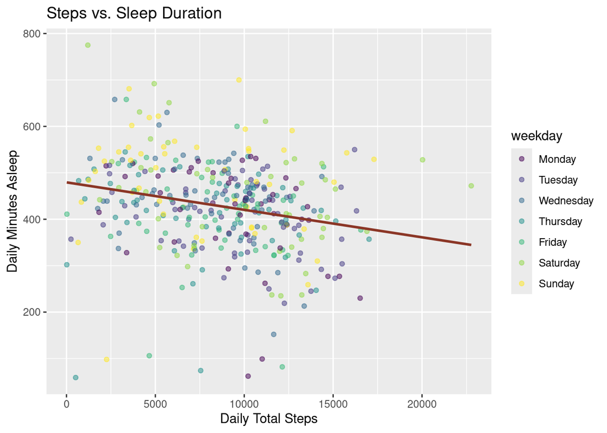

```r
# Create scatter plot of daily total steps vs. daily minutes asleep, colored by weekday
# Add a linear regression line to show trend
final_data %>%
      filter(!is.na(daily_total_steps) & !is.na(total_minutes_asleep)) %>%
  mutate(weekday = factor(weekdays(activityday),
                          levels = c("Monday", "Tuesday", "Wednesday", "Thursday", "Friday", "Saturday", "Sunday"))) %>%
  ggplot(aes(x = daily_total_steps, y = total_minutes_asleep, color = weekday))+
  geom_point(alpha = 0.5)+
  geom_smooth(method = "lm", se = FALSE, color = "tomato4")+
  labs(
    title = "Steps vs. Sleep Duration",
    x = "Daily Total Steps",
    y = "Daily Minutes Asleep"
  ) +
  scale_color_viridis_d()
```

This slightly downward trend line suggests a weak to moderate negative correlation.

We will further investigate this relationship as well, calculating the correlation:

#### 4.2.3.1 Correlation: Steps vs. Sleep

```r
# Calculate correlation between daily total steps and sleep duration
cor(final_data$daily_total_steps, final_data$total_minutes_asleep, use = "complete.obs")
```

```
## [1] -0.2327616
```

This -0.23 correlation indicates a weak negative relationship.

Looking back at both calorie exhaustion and steps when compared against sleep duration – we can infer that higher physical activity does not necessarily correlate with longer sleep duration – neither on the same day nor the following day.

It’s important to note that there are most likely other factors influencing sleep duration on which we don’t have data.

As such, Bellabeat might explore whether users would benefit from guidance on improving **sleep hygiene** rather than assuming that increased physical activity naturally leads to longer sleep. This shift in focus towards sleep *hygiene,* rather than just *duration,* will segue us into the third phase of our Exploratory Data Analysis.

But before we move to EDA Part III, we will revisit again public health guidelines and analyze health goal adherence based on daily sleep duration and step counts.

### 4.2.4 Viz: User Segmentation by Health Goal Adherence

To illustrate who is consistently meeting these key health guidelines, defined as achieving the goal at least 60% of the time, we will take the following approach:

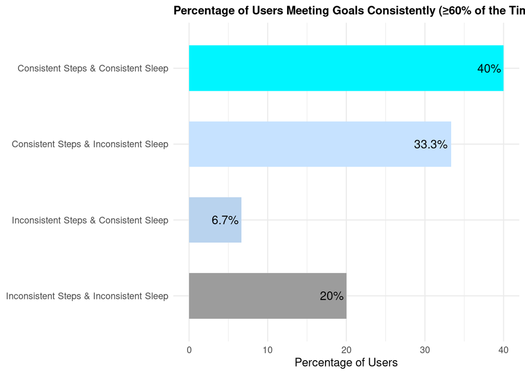

```r
# Set step and sleep thresholds
step_threshold <- 7000
sleep_threshold <- 420 # 7 hours * 60 minutes

# Create user goals based on whether each user met the thresholds
user_goals <- final_data %>%
  filter(!is.na(total_minutes_asleep), !is.na(daily_total_steps)) %>%
  mutate(
    sleep_goal_met = total_minutes_asleep >= sleep_threshold,
    step_goal_met = daily_total_steps >= step_threshold
  )

# Summarize percentage of users meeting each goal
user_summary <- user_goals %>%
  group_by(id) %>%
  summarize(
    step_pct = mean(step_goal_met) * 100,
    sleep_pct = mean(sleep_goal_met) * 100
  ) %>%
  mutate(
    step_goal = ifelse(step_pct >= 60, "Consistent Steps", "Inconsistent Steps"),
    sleep_goal = ifelse(sleep_pct >= 60, "Consistent Sleep", "Inconsistent Sleep")
  )

# Count users and calculate percentages
goal_data <- user_summary %>%
  count(step_goal, sleep_goal) %>%
  mutate(
    percent = n / sum(n) * 100,
    label = paste0(round(percent, 1), "%")
  )

# Create new factor variable for the combinations of goals
goal_data$combo <- factor(
  paste(goal_data$step_goal, "&", goal_data$sleep_goal),
  levels = c(
    "Consistent Steps & Consistent Sleep",
    "Consistent Steps & Inconsistent Sleep",
    "Inconsistent Steps & Consistent Sleep",
    "Inconsistent Steps & Inconsistent Sleep"
  )
)

# Define custom colors for each combination of goals
combo_colors <- c(
  "Consistent Steps & Consistent Sleep" = "#00F5FF",
  "Consistent Steps & Inconsistent Sleep" = "slategray1",
  "Inconsistent Steps & Consistent Sleep" = "slategray2",
  "Inconsistent Steps & Inconsistent Sleep" = "gray61"
)

# Plot the distributionn of users meeting their goals
ggplot(goal_data, aes(x = percent, y = fct_rev(combo), fill = combo))+
  geom_col(width = 0.6) +
  geom_text(aes(label = label), hjust = 1.1, color = "black", size = 4)+
  scale_fill_manual(values = combo_colors)+
  labs(
    title = "Percentage of Users Meeting Goals Consistently (≥60% of the Time)",
    x = "Percentage of Users",
    y = NULL,
    fill = NULL
  ) +
  theme_minimal() +
  theme(
    legend.position = "none",
    plot.title = element_text(hjust = 0, size = 11, face = "bold")
  )
```

We have categorized users into four groups based on whether they meet their step and sleep goals consistently (≥60% of the time) or inconsistently (<60% of the time). As the visualization illustrates, the leading category consists of users who consistently achieve both goals with 40% of users meeting both criteria; 20% of users fall short in both areas.

## 4.3 EDA Part III: Sleep Efficiency vs. Activity Variables

**Untroubled Slumber?**

As mentioned previously *(in step 4.2)*, we will reincorporate total_time_in_bed. Does daily activity correlate with how **efficiently** users sleep – or how much time they spend awake in bed? We can determine *sleep efficiency* by dividing ‘total_minutes_asleep’ by ‘total_time_in_bed.’ Let’s create a column for this new sleep efficiency variable and validate the math. Then, with sleep_efficiency calculated, we can plot its relationship with our other variables.

### 4.3.1 Create sleep_efficiency Column

```r
# Create new column for sleep efficiency
final_data <- final_data %>%
  mutate(sleep_efficiency = total_minutes_asleep / total_time_in_bed)
```

### 4.3.2 Validation: sleep_efficiency Calculation

```r
# Recalculate sleep efficiency and create maximum difference between it and new/existing 'sleep_efficiency' column
final_data %>%
  filter(!is.na(total_minutes_asleep), !is.na(total_time_in_bed)) %>%
  mutate(recalc_eff = total_minutes_asleep / total_time_in_bed) %>%
  summarize(max_diff = max(abs(recalc_eff - sleep_efficiency), na.rm = TRUE))
```

```
## # A tibble: 1 × 1
##   max_diff
##      <dbl>
## 1        0
```

Since the maximum difference is zero, this confirms that the sleep_efficiency column is accurate.

### 4.3.3 Viz: Sleep Efficiency vs. Activity Variables

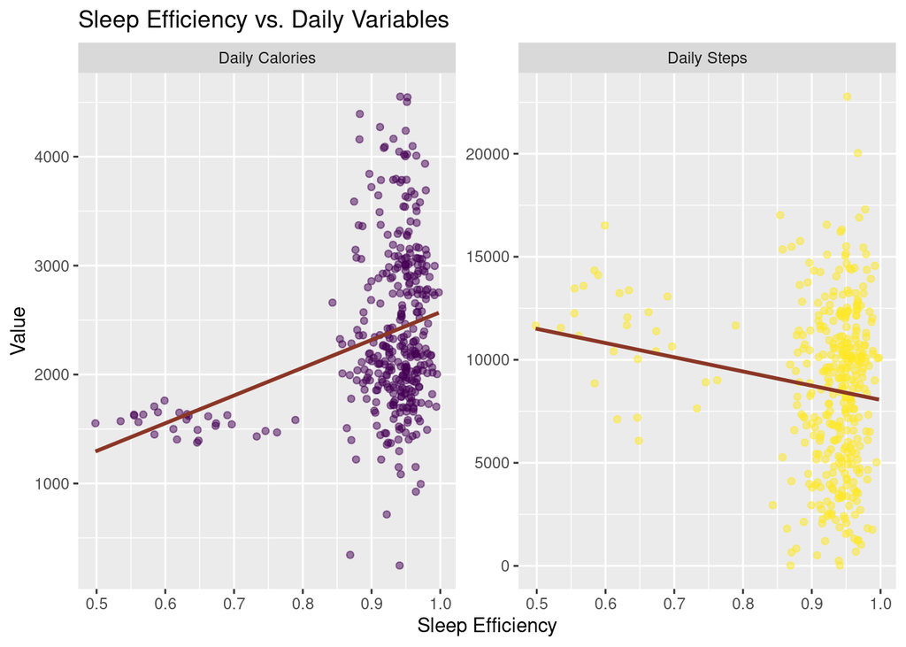

```r
# Pivot to create separate rows for calories and steps, then plot their relationship with sleep efficiency
final_data %>%
  pivot_longer(
    cols = c(daily_total_calories, daily_total_steps),
    names_to = "variable",
    values_to = "value"
  ) %>%
  mutate(
    variable = recode(variable,
                      daily_total_calories = "Daily Calories", # Rename for clarity
                      daily_total_steps = "Daily Steps")
  ) %>%
  filter(!is.na(sleep_efficiency) & !is.na(value)) %>%
  ggplot(aes(x = sleep_efficiency, y = value)) +
  geom_point(alpha = 0.5, aes(color = variable)) +
  geom_smooth(method = "lm", se = FALSE, color = "tomato4") +
  labs(
    title = "Sleep Efficiency vs. Daily Variables",
    x = "Sleep Efficiency",
    y = "Value"
  ) +
  facet_wrap (~variable, scales = "free_y")+ # Separate plots for calories and steps with different y-scales
  scale_color_viridis_d(guide = "none") # Viridis color pallete with no legend
```

Daily calorie expenditure shows a mild positive relationship with sleep efficiency, while daily steps display a mild weak negative trend. Let’s calculate the Pearson correlations in the next step.

### 4.3.2 Correlation: Sleep Efficiency vs. Activity

```r
# Calculate correlation between sleep efficiency and daily calories and steps
final_data %>%
  pivot_longer(
    cols = c(daily_total_calories, daily_total_steps),
    names_to = "variable", # New column to indicate variable type
    values_to = "value" # New column for the corresponding values
  ) %>%
  mutate(
    variable = recode(variable,
                      daily_total_calories = "Daily Calories",
                      daily_total_steps = "Daily Steps")
  ) %>%
  group_by(variable) %>% # Group by each variable to calculate separate correlations
  summarize(correlation = cor(sleep_efficiency, value, use = "complete.obs"))
```

```
## # A tibble: 2 × 2
##   variable       correlation
##   <chr>                <dbl>
## 1 Daily Calories       0.294
## 2 Daily Steps         -0.152
```

These results confirm the visualizations – suggesting that higher calorie expenditure may slightly relate to higher sleep efficiency, while more steps may slightly relate to lower sleep efficiency.

Let’s dive deeper by analyzing next-day sleep efficiency – just as we did in earlier analyses – to see how *today’s* activity might influence *tomorrow’s* sleep quality.

#### 4.3.2.1 Viz: Next-Day Sleep Efficiency vs. Daily Activity

To visualize the potential relationship between daily activities and next-day sleep efficiency, we will use the following approach:

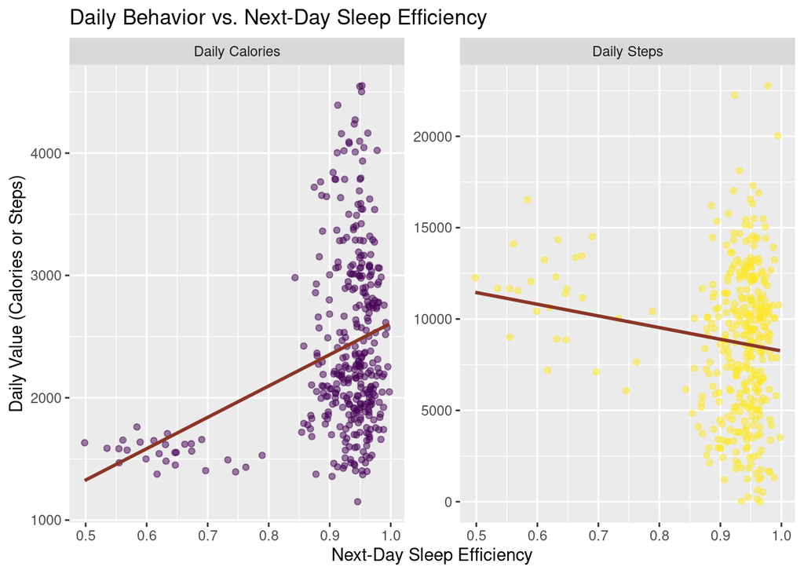

```r
# Create next-day sleep efficiency by shifting sleep metrics forward for each user
final_data <- final_data %>%
  arrange(id, activityday) %>%
  group_by(id) %>%
  mutate(next_day_sleep_efficiency = lead(total_minutes_asleep) / lead(total_time_in_bed)) %>%
  ungroup()

# Visualize relationship between next-day sleep efficiency and daily activity variables
final_data %>%
  pivot_longer(
    cols = c(daily_total_calories, daily_total_steps),
    names_to = "variable",
    values_to = "value"
  ) %>%
  mutate(
    variable = recode(variable,
                      daily_total_calories = "Daily Calories",  # Rename variable labels for clearer facet titles
                      daily_total_steps = "Daily Steps")
  ) %>%
  filter(!is.na(next_day_sleep_efficiency) & !is.na(value)) %>%
  ggplot(aes(x = next_day_sleep_efficiency, y = value, color = variable))+
  geom_point(alpha = 0.5)+
  geom_smooth(method = "lm", se = FALSE, color = "tomato4")+
  labs(title = "Daily Behavior vs. Next-Day Sleep Efficiency",
       x = "Next-Day Sleep Efficiency",
       y = "Daily Value (Calories or Steps)"
  )+
  facet_wrap(~ variable, scales = "free")+ # Create separate panels for each variable with independent y-axes
  scale_color_viridis_d(guide = "none") # Add color palette for clarity
```

Similarly, we are again seeing a slightly positive relationship between calories burned and sleep efficiency, and a slightly negative relationship between steps and sleep efficiency.

We’ll calculate these correlations in the next step.

##### 4.3.2.1.1 Correlation: Next-Day Sleep Efficiency vs. Activity

```r
# Transpose data to have variables in a single column
final_data %>%
  pivot_longer(
    cols = c(daily_total_calories, daily_total_steps),
    names_to = "variable",
    values_to = "value"
  ) %>%
  mutate(
    variable = recode(variable,
                      daily_total_calories = "Daily Calories", # Rename variables for clarity
                      daily_total_steps = "Daily Steps")
  ) %>%
  filter(!is.na(next_day_sleep_efficiency) & !is.na(value)) %>%
  group_by(variable) %>% # Group data by activity variable
  summarize(correlation = cor(next_day_sleep_efficiency, value, use = "complete.obs")) # Use only complete cases for correlation calculation
```

```
## # A tibble: 2 × 2
##   variable       correlation
##   <chr>                <dbl>
## 1 Daily Calories       0.305
## 2 Daily Steps         -0.137
```

Interestingly, calorie expenditure shows a slightly stronger connection to better next-day sleep efficiency than same-day sleep efficiency.

###### 4.3.2.1.1.1 Linear Regression Model Efficiency

Based on the stronger connections observed in the previous step, we will now build a multiple linear regression model using ‘daily_total_calories’ and ‘daily_total_steps’ to predict next-day sleep efficiency – in order to assess how well activity levels might predict sleep efficiency.

```r
# Filter to remove rows with missing values for relevant variables
regression_data <- final_data %>%
  filter(!is.na(next_day_sleep_efficiency),
         !is.na(daily_total_calories),
         !is.na(daily_total_steps))

# Fit a linear regression model to predict next day's sleep efficiency based on daily calories and steps
model <- lm(next_day_sleep_efficiency ~ daily_total_calories + daily_total_steps, data = regression_data)

# Display the summary
summary(model)
```

```
##
## Call:
## lm(formula = next_day_sleep_efficiency ~ daily_total_calories +
##     daily_total_steps, data = regression_data)
##
## Residuals:
##      Min       1Q   Median       3Q      Max
## -0.36079 -0.02339  0.01680  0.04862  0.13661
##
## Coefficients:
##                        Estimate Std. Error t value Pr(>|t|)
## (Intercept)           8.544e-01  1.500e-02  56.958  < 2e-16 ***
## daily_total_calories  4.849e-05  6.137e-06   7.901 3.35e-14 ***
## daily_total_steps    -6.069e-06  1.103e-06  -5.501 7.15e-08 ***
## ---
## Signif. codes:  0 '***' 0.001 '**' 0.01 '*' 0.05 '.' 0.1 ' ' 1
##
## Residual standard error: 0.07982 on 362 degrees of freedom
## Multiple R-squared:  0.1631, Adjusted R-squared:  0.1584
## F-statistic: 35.26 on 2 and 362 DF,  p-value: 1.018e-14
```

Key takeaways from our results:

- Calorie expenditure shows a statistically significant positive effect.
- Steps show a statistically significant negative effect.
- R-squared: at 0.1584, the model explains roughly 16% of the variation in next-day sleep efficiency. While modest, this level of predictive power is meaningful and suggests that daily activity has some influence on next-day sleep efficiency.

Next, let’s plot model predictions against actual sleep efficiency values to visualize how closely the model’s predictions match real outcomes.

###### 4.3.2.1.1.2 Model Performance: Predictions vs. Actuals Efficiency

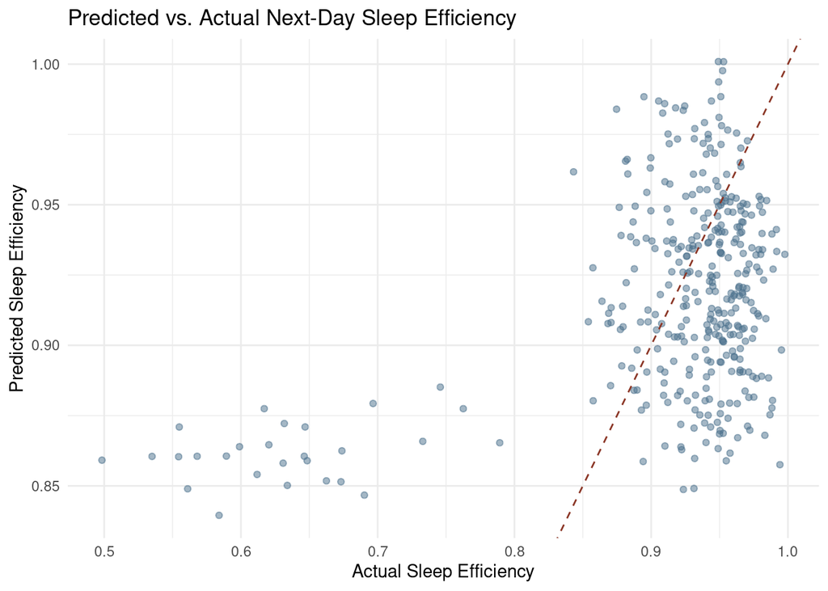

```r
# Add predicted sleep efficiency values to the regression_data dataset
regression_data <- regression_data %>%
  mutate(predicted_sleep_eff = predict(model))

# Create scatter plot comparing actual vs. predicted next-day sleep efficiency
ggplot(regression_data, aes(x = next_day_sleep_efficiency, y = predicted_sleep_eff))+
  geom_point(alpha = 0.5, color = "skyblue4")+
  geom_abline(slope = 1, intercept = 0, color = "tomato4", linetype = "dashed")+ # Add a reference line
  labs(
    title = "Predicted vs. Actual Next-Day Sleep Efficiency",
    x = "Actual Sleep Efficiency",
    y = "Predicted Sleep Efficiency"
  ) +
  theme_minimal() # Add minimalist theme
```

Finally, in the next step we’ll plot prediction errors against predicted sleep efficiency to identify any concerns with the model.

###### 4.3.2.1.1.3 Residual Analysis: Model Diagnostics

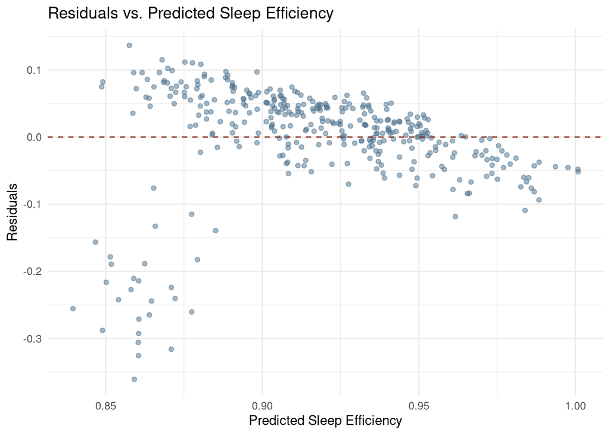

```r
# Add predicted sleep efficiency and residuals to regression_data
regression_data <- regression_data %>%
  mutate(
    predicted_sleep_eff = predict(model), # Predict sleep efficiency using the linear model
    residuals = next_day_sleep_efficiency - predicted_sleep_eff # Calculate difference between actual and predicted
  )

# Create scatter plot of residuals versus predicted sleep efficiency
ggplot(regression_data, aes(x = predicted_sleep_eff, y = residuals))+
  geom_point(alpha = 0.5, color = "skyblue4")+
  geom_hline(yintercept = 0, linetype = "dashed", color = "tomato4")+ # Add line at y = 0 to indicate no residuals
  labs(
    title = "Residuals vs. Predicted Sleep Efficiency",
    x = "Predicted Sleep Efficiency",
    y = "Residuals"
  )+
  theme_minimal() # Add minimalist theme
```

At last, we will move on to our final sections, taking with us the most relevant and impactful findings from the previous steps.

# 4.4 Key Insights & Business Recommendations

### 4.4.1 Sleep Duration Trends

**Key Takeaways**

- Sleep duration shows no strong correlation with either daily steps or calories burned – same-day or next-day *(Steps 4.2.3.1, 4.2.2.1)*.
- 53.3% of users, however, did not consistently (≥60% of the time) meet recommended sleep duration guidelines, as defined by the [CDC](https://www.cdc.gov/sleep/about/index.html#cdcreference_3) referencing standards from the National Sleep Foundation and the American Academy of Sleep Medicine and Sleep Research Society.

**Business Recommendation**

Bellabeat can send bedtime push notifications to users who frequently fall short of sleep targets, reinforcing healthy habits and long-term well-being.

### 4.4.2 Step Count Benchmarks

**Key Takeaways**

- Based on a [JAMA Network Open study](https://jamanetwork.com/journals/jamanetworkopen/fullarticle/2783711), taking at least 7,000 steps per day is associated with a 50%–70% lower risk of all-cause mortality.
- In our data, 53.125% of users met the 7,000-step threshold on average, while 46.875% did not *(Step 4.2.1.1)*.
- Users as a group averaged 7,591 daily steps *(Step 4.1.1.1)*

**Business Recommendation**

Bellabeat can implement dual user segmentation: reward users consistently meeting 7,000-step benchmark with badges, while nudging those below the benchmark to earn achievement incentives (e.g., badges), encouraging engagement and progress.

### 4.4.3 Weekend Calorie Patterns

**Key Takeaways**

- Calorie burn from walking appears consistent across weekdays and weekends *(Step 4.2.1)*.
- No major shift was observed in the calorie-versus-steps relationship by day, suggesting regular and sustained movement habits.

**Business Recommendation**

Bellabeat can promote “Weekend Wellness” campaigns that frame weekends not as time to *catch up* on missed activity, but as a **continuation** of existing healthy routines, reinforcing consistency over peaks and valleys.

### 4.4.4 Activity and Sleep Efficiency

**Key Takeaways**

**Business Recommendation**

If more research is conducted to strengthen the link between calorie burn and next-day sleep efficiency, Bellabeat can incorporate education tactics into its content marketing – perhaps running campaigns around *‘better exercise today for better sleep tomorrow’* – ultimately encouraging users to continue optimizing their health. Additionally, Bellabeat can encourage its users to engage in calorie-burning activities earlier in the day through targeted nudges, personalized workout suggestions, and community fitness challenges, all promoting movement with potential benefits for sleep.

### 4.4.5 Predictive Modeling for Sleep

**Key Takeaways**

- A linear regression model using previous-day activity metrics explains approximately 15.8% of the variability in next-day sleep efficiency *(Step 4.3.2.1.1.1)*.
- While modest, this level of predictability offers a starting point for building tailored user recommendations

**Business Recommendation**

Bellabeat should continue developing predictive models with richer user data. These models could anticipate low sleep efficiency for certain users and enable real-time nudges like earlier bedtime prompts, increasing sleep duration and health outcomes.

# 5. Conclusion

This case study analyzed non-Bellabeat smart device data to uncover behavioral trends that could inform the Bellabeat content marketing strategy and app engagement features. Key insights reveal that while many users exhibit consistent activity patterns, a substantial number still fall short of recommended health benchmarks – particularly around sleep and step goals. These patterns represent a clear opportunity for Bellabeat to offer more personalized guidance, motivation, and support through data-driven interventions.

In parallel, preliminary modeling demonstrates modest but meaningful potential to predict next-day sleep efficiency based on previous day behaviors. Although current models explains a limited portion of the variance, they point to a promising direction: with more robust, Bellabeat-specific data, future models could power highly personalized, predictive experiences for users.

To build on this foundation, Bellabeat may consider the following steps:

- Invest in broader internal data collection and user segmentation
- Use clustering and pattern recognition to personalize experiences
- Expand predictive modeling efforts for behavior forecasting
- Integrate insights into content marketing and app-based nudges

Ultimately, this analysis reinforces the potential for data to become a competitive advantage for Bellabeat. With the right infrastructure and focus, the company can deepen user engagement, enhance its brand positioning, and continue delivering on its mission to empower women through wellness technology.